# Week 14 · Repeat models without losing the evidence

MATH 346 course companion · Groups, uncertainty and sensitivity

**Note**

Use this chapter with the [companion reading guide](https://lnajman.github.io/math346/companion/how-to-use.html). **Nothing in this chapter is collected or graded.** The approved syllabus, workload guide and Blackboard remain authoritative.

## Your route

**How can we repeat one modeling question across groups without treating different months as competing models?**

We reuse the Week 13 formula for ozone, temperature and wind, changing only the monthly subset. A useful result keeps the group, sample size, fitted model, coefficient interval and diagnostics together. We then ask how a declared sensitivity refit changes the conclusion, and audit an LLM-style ranking.

Before you start · Words used here · Setup · Meeting 1 · Meeting 2 · AI audit · Practice and resources.

**TipA first 30-minute session**

Choose a stopping point within about 30 minutes and resume there later. This is an untested stopping budget, not a promise to complete every step.

1. Check prerequisites/setup; resolve access first if blocked.
2. State what stays fixed, then inspect the group counts and source IDs.
3. Read the coefficient plot with its sample-size table; compare uncertainty rather than naming a winning month.
4. Read June’s sensitivity explanation and mark the next Core checkpoint.

Read displayed output when jumping ahead; run R blocks in order when returning to your script. The full route is Core **1, 2, 4, 5, 6**, selective Guided **3, 7, 8, 9, 10**, with **no Extension exercises** in this set. Reading, selected lab checkpoints and exercises share the **90–120-minute ordinary-week practice budget**. Follow the announced reduced selection in assessment weeks. Both class meetings retain 75 minutes and their final five-minute individual exit.

### Before you start

Use [Week 12](https://lnajman.github.io/math346/companion/week-12.html) for named lists, `lapply`, typed `vapply` and keeping requested work visible, and [Week 13](https://lnajman.github.io/math346/companion/week-13.html) for complete cases, coefficient units, training metrics, residuals and Cook’s distance. You need to recognize those ideas; the complete references rebuild every object. No saved workspace or external CSV is needed.

Carry forward this sequence from Week 13: **influence flag → check the source → report sensitivity → assess new-data performance separately**. A large residual measures a gap between an observed and fitted value; Cook’s distance measures influence on the fitted relationship. Neither proves the observation is wrong. If the source confirms a genuine observation from the population being studied, keep it in the primary analysis rather than removing it just to improve fit. A declared sensitivity refit shows how much the conclusion changes.

Slides provide lecture flow, this chapter explains and checks it, and selected labs/exercises provide practice. Week 14 repeats one declared workflow; it does not search many formulas. Week 15 turns the evidence into reproducible communication.

**NoteWords used in this chapter**

| Word or pattern | Meaning here |
| --- | --- |
| **Fixed contract** | The question, formula, units, row-selection and output rules kept the same across groups. |
| **Subset / group** | The observations used for one fit; here, complete rows from one month. |
| **Factor levels** | Declared category order; May through September controls the input split. A later text column need not preserve that order in a plot. |
| **Named list** | A collection with one addressable element per group, such as `month_data[["Jun"]]`. |
| **Model object / summary** | The retained fitted `lm` object / a compact row of selected evidence from it. |
| **Schema / alignment** | Agreed output columns and types / keeping each result attached to the right request. |
| **Coefficient interval** | A model-based uncertainty interval for a coefficient, not a range of individual ozone values. |
| **Training R-squared / RMSE** | Variation accounted for / prediction-error scale on the rows used for fitting. |
| **Standardized residual / Cook’s distance** | A scaled observed-minus-fitted discrepancy / a measure of a row’s influence on the fit. |
| **Sensitivity refit** | Repeat the fixed fit after one declared change and report how the result changes. |
| **Source ID / list position** | The original observation identifier / its current location inside a subset or result list. |
| **Validation** | Evaluate the declared model on data not used to fit it; a changed training subset is not validation. |

### Read / Explain / Check / Interpret

Read the repeated unit and its inputs; explain a prediction; check alignment; interpret the result with sample size and uncertainty. Think first; write a private comment only where requested—see the [prediction guide](https://lnajman.github.io/math346/companion/how-to-use.html#read-explain-check-interpret).

## Setup

Use R 4.1 or later, `dplyr` and `ggplot2`. Save the many-model starter and sensitivity starter in a `week14/` folder. The examples use built-in `airquality`; no data download is required. The AI critique target is for selected Guided 10 work, with no AI account or external call.

Run this check from your `week14/` folder:

```r
required_files <- c("week14-many-models.R", "week14-grouped-sensitivity.R")
```

```r
missing_files <- required_files[!file.exists(required_files)]
missing_packages <- c("dplyr", "ggplot2")[!vapply(
  c("dplyr", "ggplot2"), requireNamespace, logical(1), quietly = TRUE
)]
if (length(missing_files) + length(missing_packages) == 0) {
  cat("Setup OK\n")
} else {
  cat("Missing files:", paste(missing_files, collapse = ", "), "\n")
  cat("Missing packages:", paste(missing_packages, collapse = ", "), "\n")
}
```

**Example output when both files and packages are available:**

```
Setup OK
```

Run the check on your computer; the printed example cannot confirm your setup. Use `getwd()` for a missing path and the [software checks](https://lnajman.github.io/math346/resources/software-requirements.html) for access/package help. Restart R, then run the chapter’s code in order, including the code inside the reference reveals.

The full references are independent saved scripts. Each rebuilds `model_data` and related objects; the next reference deliberately replaces them. Keep your own starters separate and compare only after attempting the selected work.

## Meeting 1 · One contract, five groups

**Slide cues:** “Hold The Contract Fixed”, “What Changes?”, “Checked Modeling Table”, “Split By Group”, “Reconcile The Split” and “Freeze The Formula”.

### Check the split before fitting

For Core 1, state one recorded New York day (May–September 1973) as the observation, ozone (ppb) as the response, temperature (degrees F) and wind (mph) as predictors, and `ozone_ppb ~ temperature_f + wind_mph` as the formula. Keep the same complete-case rule, minimum five rows, output schema and diagnostic rules. The month changes the subset; it is not an extra predictor in this formula.

**Predict in a private comment first:** five month labels are present. Does that alone show all 116 complete observations reached exactly one group? Which checks would reveal lost rows, duplicated rows or a label-order mistake?

**Compare the split reasoning**

Check names/order, counts adding to 116, and the original source IDs appearing once each. Merely returning five groups checks none of the row identities. **If your answer differed,** you may have treated group completeness as row completeness, or assumed matching totals establish identity.

Attempt Core 2’s grouped-input audit in your starter, then compare this check. Create `observation_id` before filtering; factor levels set the month order. The split contains complete cases, not all 153 source days.

```r
library(dplyr)
model_input <- airquality |>
  transmute(observation_id = row_number(),
            month = factor(month.abb[Month], levels = month.abb[5:9]),
            ozone_ppb = Ozone, temperature_f = Temp, wind_mph = Wind) |>
  filter(complete.cases(ozone_ppb, temperature_f, wind_mph))
audit_groups <- split(model_input, model_input$month)
group_audit <- model_input |>
  group_by(month) |>
  summarize(n = n(), temperature_min = min(temperature_f),
            temperature_max = max(temperature_f), wind_min = min(wind_mph),
            wind_max = max(wind_mph), .groups = "drop")
split_ids <- unlist(lapply(audit_groups, function(d) d$observation_id),
                    use.names = FALSE)
stopifnot(
  nrow(model_input) == 116,
  identical(names(audit_groups), month.abb[5:9]),
  identical(unname(vapply(audit_groups, nrow, integer(1))),
            c(26L, 9L, 26L, 26L, 29L)),
  sum(group_audit$n) == 116,
  !anyDuplicated(split_ids),
  identical(sort(split_ids), model_input$observation_id),
  all(group_audit$temperature_min < group_audit$temperature_max),
  all(group_audit$wind_min < group_audit$wind_max)
)
print(group_audit, width = Inf)
```

```
# A tibble: 5 × 6
  month     n temperature_min temperature_max wind_min wind_max
  <fct> <int>           <int>           <int>    <dbl>    <dbl>
1 May      26              57              81      5.7     20.1
2 Jun       9              65              90      8       20.7
3 Jul      26              73              92      4.1     14.9
4 Aug      26              72              97      2.3     15.5
5 Sep      29              63              93      2.8     16.6
```

The monthly counts are 26, 9, 26, 26 and 29. `split` returns a list, not a combined table: `audit_groups[["Jun"]]` is June’s nine-row data frame. The original IDs stay attached even though positions change inside each subset. A silent `stopifnot` means its conditions passed; an error names the failed condition. Inspect that input rather than deleting the check.

### Retain the fitted object with its evidence

**Slide cues:** “One-Group Contract”, “Return More Than A Number”, “Test May First”, “Repeat The Checked Unit”, “Name The Results”, “Extract Summary Rows” and “Check The Batch”.

**Predict in a private comment first:** for Core 1/4, state your function’s intended input and return components before expanding the reference. In your starter, keep the model object as well as the summary. A coefficient alone cannot later supply residuals, intervals or the fitted formula.

Read the `fit_one_month` definition first. Its return list has `month`, `formula`, `fit` and `summary`. `lapply` returns one such record per month; `names(model_results)` restores the requested labels to that result list. The second `lapply` extracts each `result$summary`, and `bind_rows` combines compatible rows. `vapply(..., character(1))` checks that formula text is one character value per result, not an arbitrary-length object.

Guided 3 tests May and expected failures before automation in your own starter. The complete supplied reference below defines the function and executes the five-group batch; it does not separately print a May-only test.

**Reference version · Retain all five models**

A useful contract takes prepared one-month data, a month label and the fixed formula, and returns `month`, `formula`, the fitted `lm` object and one summary row. Keep sample size, coefficients, interval and training metrics in that row. **If your answer differed,** you may have kept only a coefficient or omitted the group label, retained fit or uncertainty needed for later checking.

```r
# MATH 346 - possible worked solution
# Compare only after attempting the starter; other correct implementations are possible.

library(dplyr)
library(ggplot2)

model_data <- airquality |>
  transmute(
    observation_id = row_number(),
    month = factor(month.abb[Month], levels = month.abb[5:9]),
    ozone_ppb = Ozone,
    temperature_f = Temp,
    wind_mph = Wind
  ) |>
  filter(complete.cases(ozone_ppb, temperature_f, wind_mph))

fixed_formula <- ozone_ppb ~ temperature_f + wind_mph
month_data <- split(model_data, model_data$month)

fit_one_month <- function(data, month_name, model_formula) {
  required <- c("month", "ozone_ppb", "temperature_f", "wind_mph")
  if (!is.data.frame(data) || !all(required %in% names(data))) {
    stop("group data do not satisfy the required column contract")
  }
  if (nrow(data) < 5 || length(unique(data$month)) != 1) {
    stop("each group needs one month and at least five observations")
  }
  if (sd(data$temperature_f) == 0 || sd(data$wind_mph) == 0) {
    stop("each predictor must vary within the group")
  }

  fit <- lm(model_formula, data = data)
  intervals <- confint(fit)
  predictions <- predict(fit)

  summary_row <- tibble(
    month = month_name,
    n_observations = nrow(data),
    temperature_slope = coef(fit)[["temperature_f"]],
    temperature_low = intervals["temperature_f", 1],
    temperature_high = intervals["temperature_f", 2],
    wind_slope = coef(fit)[["wind_mph"]],
    training_rmse_ppb = sqrt(mean((data$ozone_ppb - predictions)^2)),
    r_squared = summary(fit)$r.squared
  )

  list(
    month = month_name,
    formula = model_formula,
    fit = fit,
    summary = summary_row
  )
}

model_results <- lapply(
  names(month_data),
  function(month_name) {
    fit_one_month(month_data[[month_name]], month_name, fixed_formula)
  }
)
names(model_results) <- names(month_data)

model_summary <- bind_rows(lapply(model_results, function(result) result$summary))
formula_text <- vapply(
  model_results,
  function(result) paste(deparse(result$formula), collapse = " "),
  character(1)
)

expected_slopes <- c(
  May = 1.642119,
  Jun = 1.637785,
  Jul = 3.743456,
  Aug = 1.974714,
  Sep = 2.027110
)

stopifnot(
  identical(names(model_results), month.abb[5:9]),
  identical(model_summary$month, month.abb[5:9]),
  identical(model_summary$n_observations, c(26L, 9L, 26L, 26L, 29L)),
  sum(model_summary$n_observations) == nrow(model_data),
  length(unique(formula_text)) == 1,
  all(model_summary$temperature_low < model_summary$temperature_slope),
  all(model_summary$temperature_slope < model_summary$temperature_high),
  max(abs(model_summary$temperature_slope - expected_slopes)) < 1e-6,
  all(vapply(model_results, function(result) inherits(result$fit, "lm"), logical(1)))
)

coefficient_plot <- ggplot(
  model_summary,
  aes(x = month, y = temperature_slope)
) +
  geom_hline(yintercept = 0, linetype = "dashed") +
  geom_errorbar(
    aes(ymin = temperature_low, ymax = temperature_high),
    width = 0.15
  ) +
  geom_point(size = 2) +
  labs(
    x = "Month",
    y = "Temperature coefficient (ozone ppb per degree F)"
  )

coefficient_build <- ggplot_build(coefficient_plot)
stopifnot(nrow(coefficient_build$data[[3]]) == nrow(model_summary))

print(model_summary)
```

```
# A tibble: 5 × 8
  month n_observations temperature_slope temperature_low temperature_high
  <chr>          <int>             <dbl>           <dbl>            <dbl>
1 May               26              1.64          0.382              2.90
2 Jun                9              1.64          0.204              3.07
3 Jul               26              3.74          1.72               5.77
4 Aug               26              1.97          0.0840             3.87
5 Sep               29              2.03          1.27               2.78
# ℹ 3 more variables: wind_slope <dbl>, training_rmse_ppb <dbl>,
#   r_squared <dbl>
```

```r
cat("Week 14 fitted one checked model for every requested month.\n")
```

```
Week 14 fitted one checked model for every requested month.
```

The helper checks required columns, one month, minimum row count and predictor variation; preprocessing supplied the complete rows. The caller passes the same formula each time, and the batch checks its text. These are teaching checks, not an exhaustive validator for arbitrary inputs. If a group fails, this `lapply` batch **stops**; it does not return a status row for the failed group. Keep the requested group list visible and investigate the failure rather than silently dropping the group. The Week 12 status-log pattern is available when a task calls for mixed success/error records.

### Read estimates with intervals and sample sizes

**Slide cues:** “Retain Beside Every Estimate”, “Plot Estimate And Interval”, “Why Intervals Matter” and “Different Rows, Different Questions”.

These checks use the reference object names. Run the full reference above first; if your completed starter uses other names, adapt the names in these checks.

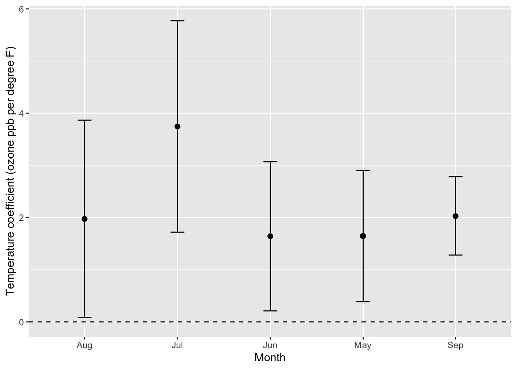

```r
print(coefficient_plot)
```

```r
print(model_summary[, c("month", "n_observations", "temperature_slope",
                        "temperature_low", "temperature_high")], width = Inf)
```

```
# A tibble: 5 × 5
  month n_observations temperature_slope temperature_low temperature_high
  <chr>          <int>             <dbl>           <dbl>            <dbl>
1 May               26              1.64          0.382              2.90
2 Jun                9              1.64          0.204              3.07
3 Jul               26              3.74          1.72               5.77
4 Aug               26              1.97          0.0840             3.87
5 Sep               29              2.03          1.27               2.78
```

```r
stopifnot(all(vapply(model_results, function(result) {
  identical(paste(deparse(formula(result$fit)), collapse = " "),
            paste(deparse(fixed_formula), collapse = " "))
}, logical(1))))
```

Each point is a temperature coefficient in ppb per degree F, holding wind fixed. Each vertical bar is its 95% model-based coefficient interval; the dashed line is zero. Read the adjacent sample-size table with the plot. These are intervals for coefficients under the model assumptions, not ranges containing 95% of individual ozone readings.

In the returned summary, `month` is text, so this plot orders its labels alphabetically (Aug, Jul, Jun, May, Sep). The table remains in May–September order. Use the labels to match each point to its table row, rather than assuming the positions coincide.

**Predict · Think first:** June has the fewest rows. Must it have the widest temperature interval? Does July’s highest point estimate establish the largest true effect?

**Compare what the display supports**

June has nine rows, but July’s temperature interval is widest in this example. Width also depends on the observed predictor information and residual spread; sample size alone does not determine it. July’s point estimate is about 3.74, while the other estimates are roughly 1.64–2.03. Retain the intervals rather than treating those point estimates as exact group effects.

**If your answer differed,** you may have used only sample size or only the coefficient column. Interval overlap alone does not prove equal effects, either. These remain observational associations, not causal effects.

For Core 6, useful statements connect the estimate to its evidence: June has only nine complete rows; July’s estimated temperature association is larger but has substantial uncertainty; September has 29 rows and its own observed conditions. They do not define a common predictive competition. Same formula and units make summaries align; they do not make different rows interchangeable.

**Individual in-class exit, final five minutes:** Across our five monthly fits, name two parts of the modeling contract that must stay fixed. Explain why five summary rows alone do not prove that every requested month was fitted exactly once, and name a check that would reveal a missing or duplicated month. Write a short individual response in your own words. Code is not required. Submit your individual response in Blackboard.

**Self-check (no submission):** a result table still has five rows after a bug, but `Jun` appears twice and `Aug` disappears. Why is a row-count check inadequate, and which requested-versus-returned comparison would expose it?

**Compare the Meeting 1 self-check**

Five rows can contain the wrong labels. Compare the returned month names and order with `names(month_data)` or `month.abb[5:9]`, and require one summary for each requested group. Counts and names test different promises; retain both.

## Meeting 2 · Repeat diagnostics and a declared sensitivity rule

**Slide cues:** “Meeting 2 Question”, “One Diagnostic Record Per Group”, “Preserve Source Identity”, “Sensitivity Refit”, “Sensitivity Is A Question”, “Classroom Result” and “Why Training Error Falls”.

### Keep the selected row traceable

Use this section selectively with Guided 7/8/9. It supplies evidence for Core 6’s cautious comparisons, not an extra full assignment. The complete reference and following evidence check can run in a fresh session independently of Meeting 1.

The declared rule selects the largest **absolute standardized residual** in each month, removes that one row for a sensitivity refit, and keeps the same formula. It is not a rule selecting the largest Cook’s distance. `removed_index` is a position within that month; `data$observation_id[[removed_index]]` recovers the original source ID. `data[-removed_index, , drop = FALSE]` keeps the remaining rows as a data frame. No original source row is deleted from `airquality`.

Before expanding, identify that rule in your starter and predict which evidence must remain beside every sensitivity coefficient: group, original/retained size, selected source ID, original coefficient and both training-error records.

**Reference version · Grouped diagnostics and sensitivity**

```r
# MATH 346 - possible worked solution
# Compare only after attempting the starter; other correct implementations are possible.

library(dplyr)

model_data <- airquality |>
  transmute(
    observation_id = row_number(),
    month = factor(month.abb[Month], levels = month.abb[5:9]),
    ozone_ppb = Ozone,
    temperature_f = Temp,
    wind_mph = Wind
  ) |>
  filter(complete.cases(ozone_ppb, temperature_f, wind_mph))

month_data <- split(model_data, model_data$month)
fixed_formula <- ozone_ppb ~ temperature_f + wind_mph

rmse <- function(observed, predicted) {
  stopifnot(length(observed) == length(predicted), !anyNA(observed), !anyNA(predicted))
  sqrt(mean((observed - predicted)^2))
}

diagnose_one_month <- function(data, month_name) {
  fit <- lm(fixed_formula, data = data)
  standardized <- rstandard(fit)
  cook <- cooks.distance(fit)
  removed_index <- which.max(abs(standardized))

  sensitivity_data <- data[-removed_index, , drop = FALSE]
  sensitivity_fit <- lm(fixed_formula, data = sensitivity_data)

  original_slope <- coef(fit)[["temperature_f"]]
  sensitivity_slope <- coef(sensitivity_fit)[["temperature_f"]]

  tibble(
    month = month_name,
    n_observations = nrow(data),
    standardized_residual_flags = sum(abs(standardized) > 2),
    cooks_distance_flags = sum(cook > 4 / nrow(data)),
    sensitivity_removed_observation_id = data$observation_id[[removed_index]],
    original_temperature_slope = original_slope,
    sensitivity_temperature_slope = sensitivity_slope,
    slope_change_percent =
      100 * (sensitivity_slope - original_slope) / abs(original_slope),
    original_training_rmse_ppb = rmse(data$ozone_ppb, predict(fit)),
    sensitivity_training_rmse_ppb =
      rmse(sensitivity_data$ozone_ppb, predict(sensitivity_fit))
  )
}

sensitivity_table <- bind_rows(lapply(
  names(month_data),
  function(month_name) {
    diagnose_one_month(month_data[[month_name]], month_name)
  }
))

stopifnot(
  nrow(sensitivity_table) == length(month_data),
  identical(sensitivity_table$month, month.abb[5:9]),
  identical(
    sensitivity_table$standardized_residual_flags,
    c(1L, 1L, 2L, 1L, 2L)
  ),
  identical(
    sensitivity_table$cooks_distance_flags,
    c(2L, 2L, 2L, 1L, 3L)
  ),
  identical(
    sensitivity_table$sensitivity_removed_observation_id,
    c(30L, 49L, 62L, 117L, 124L)
  ),
  all(sensitivity_table$sensitivity_training_rmse_ppb <
        sensitivity_table$original_training_rmse_ppb),
  sum(abs(sensitivity_table$slope_change_percent) > 40) == 3
)

print(sensitivity_table)
```

```
# A tibble: 5 × 10
  month n_observations standardized_residual_flags cooks_distance_flags
  <chr>          <int>                       <int>                <int>
1 May               26                           1                    2
2 Jun                9                           1                    2
3 Jul               26                           2                    2
4 Aug               26                           1                    1
5 Sep               29                           2                    3
# ℹ 6 more variables: sensitivity_removed_observation_id <int>,
#   original_temperature_slope <dbl>, sensitivity_temperature_slope <dbl>,
#   slope_change_percent <dbl>, original_training_rmse_ppb <dbl>,
#   sensitivity_training_rmse_ppb <dbl>
```

```r
cat("Lower sensitivity training error follows removal of a difficult row; it is not new-data validation.\n")
```

```
Lower sensitivity training error follows removal of a difficult row; it is not new-data validation.
```

```r
cat("Week 14 grouped sensitivity checks passed.\n")
```

```
Week 14 grouped sensitivity checks passed.
```

These checks use the reference object names. Run the reference above first, or adapt the names to your own completed starter.

```r
selected_rows <- airquality[sensitivity_table$sensitivity_removed_observation_id,
                            c("Ozone", "Temp", "Wind", "Month", "Day")]
stopifnot(
  identical(month.abb[selected_rows$Month], sensitivity_table$month),
  identical(sensitivity_table$n_observations - 1L, c(25L, 8L, 25L, 25L, 28L))
)
print(cbind(source_id = sensitivity_table$sensitivity_removed_observation_id,
            selected_rows))
```

```
    source_id Ozone Temp Wind Month Day
30         30   115   79  5.7     5  30
49         49    20   65  9.2     6  18
62         62   135   84  4.1     7   1
117       117   168   81  3.4     8  25
124       124    96   91  6.9     9   1
```

```r
print(sensitivity_table, width = Inf)
```

```
# A tibble: 5 × 10
  month n_observations standardized_residual_flags cooks_distance_flags
  <chr>          <int>                       <int>                <int>
1 May               26                           1                    2
2 Jun                9                           1                    2
3 Jul               26                           2                    2
4 Aug               26                           1                    1
5 Sep               29                           2                    3
  sensitivity_removed_observation_id original_temperature_slope
                               <int>                      <dbl>
1                                 30                       1.64
2                                 49                       1.64
3                                 62                       3.74
4                                117                       1.97
5                                124                       2.03
  sensitivity_temperature_slope slope_change_percent original_training_rmse_ppb
                          <dbl>                <dbl>                      <dbl>
1                         0.892                -45.7                       17.6
2                         2.83                  72.9                       10.6
3                         4.25                  13.4                       18.1
4                         2.94                  48.7                       25.0
5                         1.77                 -12.8                       12.7
  sensitivity_training_rmse_ppb
                          <dbl>
1                         10.7
2                          5.47
3                         13.9
4                         18.1
5                         11.3
```

The selected source IDs are **30, 49, 62, 117 and 124**, in May–September order. A source ID is not its row position inside the month. In the five monthly fits, the standardized-residual flag counts are **1, 1, 2, 1, 2**, and Cook’s-distance counts are **2, 2, 2, 1, 3**. The Cook’s threshold is `4 / n` for **each month’s** size; June’s threshold is `4/9`, not the pooled Week 13 threshold `4/116`. A row meeting both flags is still one observation.

**Predict · Think first:** June’s refitted temperature slope is about 2.83. Using the more precise values 1.6378 before and 2.8319 after, calculate the approximate percentage change and identify the denominator. If its training RMSE falls, have we shown that removing the row improved future prediction?

**Compare the sensitivity reading**

The change is positive: the script computes `100 * (sensitivity_slope - original_slope) / abs(original_slope)`, about +72.9% for June. Using the displayed rounded coefficients gives approximately the same percentage. The denominator is the magnitude of the original slope, not the refitted slope. A percent change would need special handling if that original slope were zero; it is nonzero in these supplied fits.

June now uses eight rather than nine rows. Its difficult row was selected using the original fitted model. Lower error on the changed, selected training subset is not a fair same-row validation comparison. **If your answer differed,** you may have changed the denominator or mistaken a refit on easier training rows for evidence on new observations.

Three temperature coefficients change by more than 40% in magnitude: May (about -45.7%), June (+72.9%) and August (+48.7%). July changes about +13.4% and September -12.8%. Here all five sensitivity training RMSEs decrease. Report the coefficient changes as evidence of fragility; a lower error does not make the removed observations erroneous or approve a data-cleaning rule.

## Guided audit · Sorting a table does not define a winner

**Slide cues:** “Generated Ranking”, “AI Claim: September Is Best”, “AI Claim: Wind Raises June Ozone”, “AI Claim: Ranking Will Persist” and “AI Claim: Diagnostics Do Not Matter”.

Use selectively for Guided 10. Read the supplied candidate first:

> “September is the best model because it has the highest R-squared. June proves that higher wind increases ozone. The ranking will hold for future observations, and diagnostics do not change the conclusion.”

The sorting rule is `arrange(desc(r_squared))`: order by decreasing training R-squared. Before accepting the conclusion, inspect this evidence:

| Claim | Evidence to check |
| --- | --- |
| Best monthly model | Whether all models predict the same observations for one declared criterion |
| Wind increases June ozone | Study design, June sample size and wind coefficient interval |
| Ranking persists on new observations | Where the ranking metrics were evaluated |
| Diagnostics do not matter | Group flags and declared sensitivity changes |

**Predict in a private comment first:** choose one claim, name the output or design fact you would inspect, then write a defensible replacement before opening the audit. A successful sort or a confident sentence is not evidence that the scientific comparison is defined.

**Compare the evidence and run the supplied audit**

```r
library(dplyr)

model_data <- airquality |>
  transmute(
    observation_id = row_number(),
    month = factor(month.abb[Month], levels = month.abb[5:9]),
    ozone_ppb = Ozone,
    temperature_f = Temp,
    wind_mph = Wind
  ) |>
  filter(complete.cases(ozone_ppb, temperature_f, wind_mph))

month_data <- split(model_data, model_data$month)

summarize_model <- function(data, month_name) {
  fit <- lm(ozone_ppb ~ temperature_f + wind_mph, data = data)
  intervals <- confint(fit)
  standardized <- rstandard(fit)
  cook <- cooks.distance(fit)
  removed_index <- which.max(abs(standardized))
  sensitivity_fit <- lm(
    ozone_ppb ~ temperature_f + wind_mph,
    data = data[-removed_index, , drop = FALSE]
  )

  tibble(
    month = month_name,
    n_observations = nrow(data),
    r_squared = summary(fit)$r.squared,
    wind_slope = coef(fit)[["wind_mph"]],
    wind_low = intervals["wind_mph", 1],
    wind_high = intervals["wind_mph", 2],
    diagnostic_flags =
      sum(abs(standardized) > 2 | cook > 4 / nrow(data)),
    temperature_slope_change_percent = 100 *
      (coef(sensitivity_fit)[["temperature_f"]] -
         coef(fit)[["temperature_f"]]) /
      abs(coef(fit)[["temperature_f"]])
  )
}

evidence <- bind_rows(lapply(
  names(month_data),
  function(month_name) summarize_model(month_data[[month_name]], month_name)
))

# Generated ranking: different group-specific models are treated as competitors
# and only training R-squared is considered.
generated_ranking <- evidence |>
  arrange(desc(r_squared)) |>
  transmute(rank = row_number(), month, r_squared)

generated_claim <- paste(
  "September is the best model because it has the highest R-squared.",
  "June proves that higher wind increases ozone.",
  "The ranking will hold for future observations, and diagnostics do not",
  "change the conclusion."
)

june <- evidence |>
  filter(month == "Jun")

audit <- tibble(
  generated_claim = c(
    "September is the best model",
    "June proves wind increases ozone",
    "training ranking will hold for future observations",
    "diagnostics do not affect the conclusion"
  ),
  verdict = rep("unsupported", 4),
  evidence = c(
    "each monthly model is fitted to a different subset rather than competing on the same rows",
    "June has nine rows and its wind interval includes zero",
    "all ranking metrics are calculated on training subsets",
    "every month has diagnostic flags and three slopes change by over 40 percent in sensitivity fits"
  )
)

stopifnot(
  identical(generated_ranking$month, c("Sep", "Jul", "Jun", "Aug", "May")),
  june$n_observations == 9,
  june$wind_low < 0,
  june$wind_high > 0,
  all(evidence$diagnostic_flags > 0),
  sum(abs(evidence$temperature_slope_change_percent) > 40) == 3,
  nrow(audit) == 4
)

print(generated_ranking)
```

```
# A tibble: 5 × 3
   rank month r_squared
  <int> <chr>     <dbl>
1     1 Sep       0.712
2     2 Jul       0.661
3     3 Jun       0.621
4     4 Aug       0.586
5     5 May       0.347
```

```r
cat(generated_claim, "\n\n")
```

```
September is the best model because it has the highest R-squared. June proves that higher wind increases ozone. The ranking will hold for future observations, and diagnostics do not change the conclusion.
```

```r
print(audit)
```

```
# A tibble: 4 × 3
  generated_claim                                    verdict     evidence
  <chr>                                              <chr>       <chr>
1 September is the best model                        unsupported each monthly m…
2 June proves wind increases ozone                   unsupported June has nine …
3 training ranking will hold for future observations unsupported all ranking me…
4 diagnostics do not affect the conclusion           unsupported every month ha…
```

```r
cat("Week 14 AI model-ranking audit passed.\n")
```

```
Week 14 AI model-ranking audit passed.
```

The sort returns **Sep, Jul, Jun, Aug, May** correctly for this training metric. It assesses different subsets, not common validation observations. June’s wind slope is about +1.97 ppb per mph, but its interval is about **-0.93 to 4.88** and its sample has nine rows. The point estimate does not establish a causal effect; its uncertainty also prevents a confident positive-association claim here. July’s and August’s wind intervals lie wholly below zero, whereas June’s spans both signs: read uncertainty beside a surprising sign rather than concluding that June has a real reversed effect or that its estimate is proven noise. Even an interval wholly above zero would not turn this observational design into an experiment.

Every month has at least one diagnostic flag, and three temperature slopes change by over 40% under the declared sensitivity rule. These facts belong beside the training metrics rather than being discarded by a ranking table.

A defensible replacement describes the five sample sizes, conditional coefficient estimates with intervals, diagnostics and sensitivity, and states that future-observation performance has not been measured. **If your answer differed,** you may have mistaken the highest number in a sorted column for answering a common prediction question.

Read every line and claim you accept from an LLM; retain the checks required by the [course AI policy](https://lnajman.github.io/math346/syllabus/ai-policy.html). Do not provide private student information or assessment keys to external tools.

**Individual in-class exit, final five minutes:** June has only nine complete observations. After removing the row with the largest absolute standardized residual and refitting the same formula, its temperature coefficient changes by about +73% and its training RMSE falls. What does this show, and what does it not show? Name one piece of evidence needed before claiming better prediction on new observations. Write a short individual response in your own words. Code is not required. Submit your individual response in Blackboard.

**Self-check (no submission):** a sensitivity result has lower training RMSE after removing the declared row, but the temperature coefficient changes by +73%. Write one supported statement and one statement that would go beyond that evidence.

**Compare the Meeting 2 self-check**

Supported: the coefficient is sensitive to that declared one-row change, and error is smaller on the changed training subset. The original RMSE uses nine rows; the sensitivity RMSE uses eight after selecting a difficult row to omit. The metrics describe different observations, so the decrease does not establish better prediction on new observations.

Unsupported: deletion fixed bad data or improved future prediction. Inspect the source observation and report instability instead of hiding the original result. Evidence for new-data performance would include predictions and errors on held-out observations not used to fit or select the model, with a suitable baseline evaluated on those same observations.

## Practice, recovery and next steps

| Work | Practice supported here |
| --- | --- |
| **Core 1, 2** | Freeze the contract and audit groups, source rows and predictor ranges |
| **Core 4, 5** | Keep five aligned fits and summaries; plot coefficients with intervals/sample sizes |
| **Core 6** | Make cautious group comparisons without a false winner |
| **Guided 3, 7, 8, 9, 10** | Test one group and failures, repeat diagnostics, trace IDs, assess sensitivity and audit generated rankings; use selectively |
| **Extension** | None in this set |

The references support selected main-lab checkpoints; they are not extra scripts to submit. Keep checked work for your own use and any checkpoint explicitly requested on Blackboard.

**Possible solutions · Compare after your attempt**

- Many-model possible solution
- Sensitivity possible solution

These are unchanged public comparison files; other correct implementations are possible. Keep checks whose purpose you can explain.

If an object is missing, run its defining reference or adapt the check names to your own script. If a batch fails, inspect the first failing group and its predictor ranges before repeating. If a coefficient seems surprising, check the model, units, sample size, interval and selected source row before changing any observation.

**Project 2:** preserve the frozen formula and declared sensitivity procedure. Follow the Blackboard announcement for the frozen-plan gate and validation file availability. When your validation package is released, apply the recorded formula, keep one prediction per validation row, and report deviations rather than silently revising the plan. The monthly workflow is a classroom example, not an additional project requirement. Use the [project instructions](https://lnajman.github.io/math346/projects/project-2-modeling.html) and [milestone map](https://lnajman.github.io/math346/projects/project-milestones.html). Week 15 focuses on communicating and reproducing the evidence.

**Where this fits:** [Week 14 notes](https://lnajman.github.io/math346/weeks/week-14.html) · [Slides](https://lnajman.github.io/math346/slides/week-14.html) · [Main lab](https://lnajman.github.io/math346/labs/lab-14-many-models.html) · [AI-review lab](https://lnajman.github.io/math346/labs/lab-14-ai-model-ranking.html) · [Exercises](https://lnajman.github.io/math346/weeks/week-14-exercises.html).

[Published companion chapters](https://lnajman.github.io/math346/companion/index.html).